# Day 24 - 10/16/2024

## Model selection

Recall Figure 2 in [Hooten et al. (2015)](https://esajournals.onlinelibrary.wiley.com/doi/full/10.1890/14-0661.1).

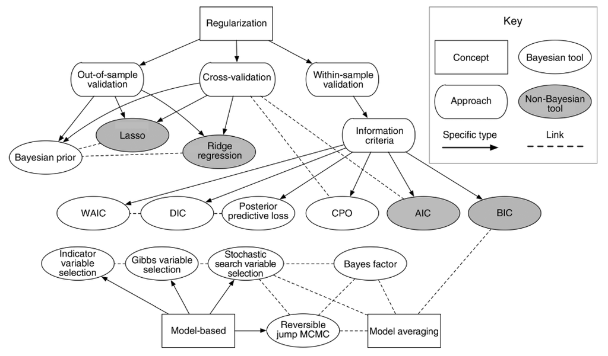

- $AIC = 2p - 2\log(\hat{L})$
- $BIC = \log (n) \cdot p - 2\log(\hat{L})$
- $R_{adj} = R^2 - (1 - R^2) \frac{p-1}{n-p}$
- Cross validation (k-fold, leave-one-out)
- $RMSE = \sqrt{\frac{1}{n}\sum_{i=1}^{n}(y_i - \hat{y_i})}$
- FYI. Consider that $MSE(\hat\theta) = Bias(\hat{\theta}, \theta) + Var(\hat{\theta})$ whenever you are evaluating models.

## Model-based model selection

- These methods are sometimes a useful alternative for scenarios where the predictors present collinearity.
- regularization, shrinkage, penalization.

### Refresh: Ordinary Least Squares Regression

$$\hat{\beta}_{OLS}=(\mathbf{X}^\top\mathbf{X})^{-1}\mathbf{X}^\top\mathbf{y}$$

### Ridge Regression

```r
library(glmnet)
```

This data example was used in [Zou and Hastie (2005)](https://academic.oup.com/jrsssb/article/67/2/301/7109482) and is available for easy download [here](https://www.kaggle.com/datasets/soujanyahp/prostate-cancer-dataset).

```r
dd <- read.csv("data/prostate.csv")
names(dd)
```

```
##  [1] "lcavol"  "lweight" "age"     "lbph"    "svi"     "lcp"     "gleason"
##  [8] "pgg45"   "lpsa"    "train"
```

```r
y <- dd$lpsa # log prostate-specific antigen
X <- model.matrix(lpsa ~ ., dd[,-10])[, -1]
```

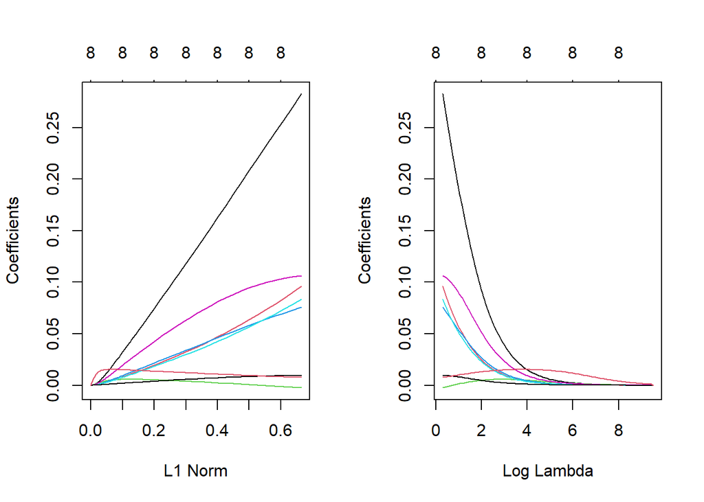

```r
m_ridge <- glmnet(X, y, family = c("gaussian"), alpha = 0, standardize  = FALSE)
par(mfrow = c(1, 2))
plot(m_ridge)
plot(m_ridge, xvar = "lambda", label = TRUE)
```

### Lasso Regression

- Lasso = Least absolute shrinkage and selection operator
- Solve $\underset{\beta_0, \beta }{\text{argmin}} = \left\{ \sum_{i=1}^{N}(y_i - \beta_0 - x_i^T \beta)^2 \right\} \text{subject to} \sum_{j=1}^{p}|\beta_j| \leq t$.
- $\hat{\beta}$ does not have a closed form solution.
- As penalization increases, the $\beta$ estimates can become zero.
- Not great for cases with collinearity. Elastic net is a better alternative.
- Problems with high-dimensional data (e.g., genetics data). Elastic net is a better alternative.

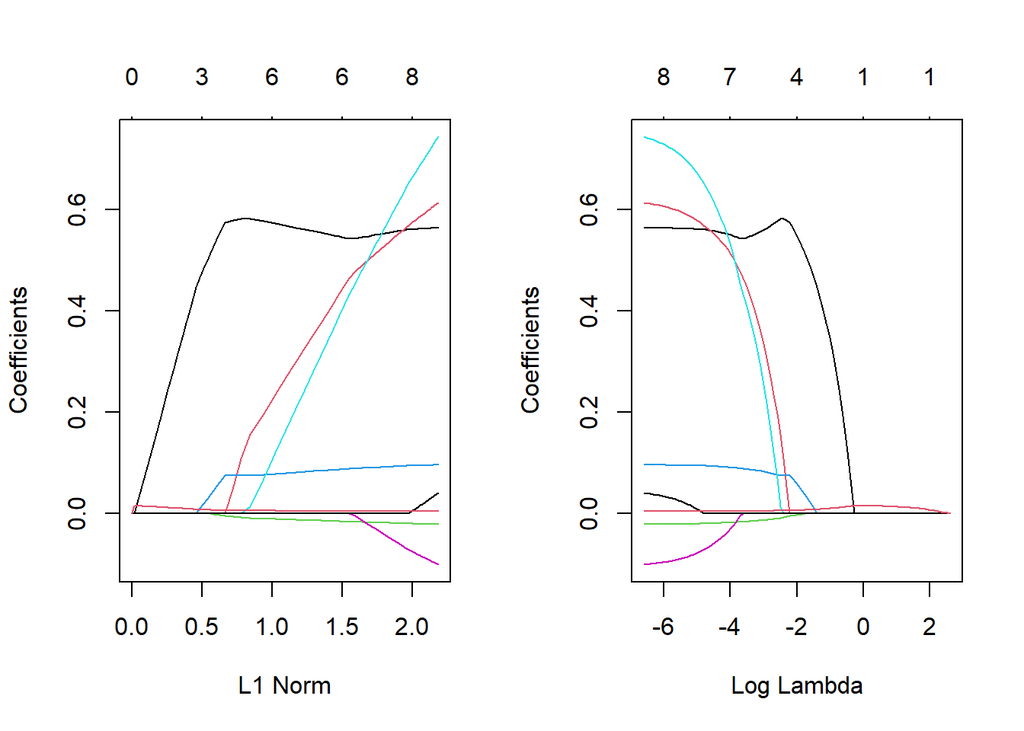

```r
fit_lasso <- glmnet(X, y, family = c("gaussian"), alpha = 1, standardize  = FALSE)
par(mfrow = c(1, 2))
plot(fit_lasso)
plot(fit_lasso, xvar = "lambda", label = TRUE)
```

### Elastic Net Regression

- Combines the L1 (Lasso) and L2 (Ridge) regularization penalties.
- $\hat{\beta} \equiv \underset{\beta}{\text{argmin}}(||y-\mathbf{X}\beta||^2 +\lambda_2||\beta||^2 +\lambda_1||\beta||_1)$, where $||\beta||_1 = \sum_{j=1}^{p}|\beta_j|$.
- Ridge and Lasso are special cases of Elastic Net.

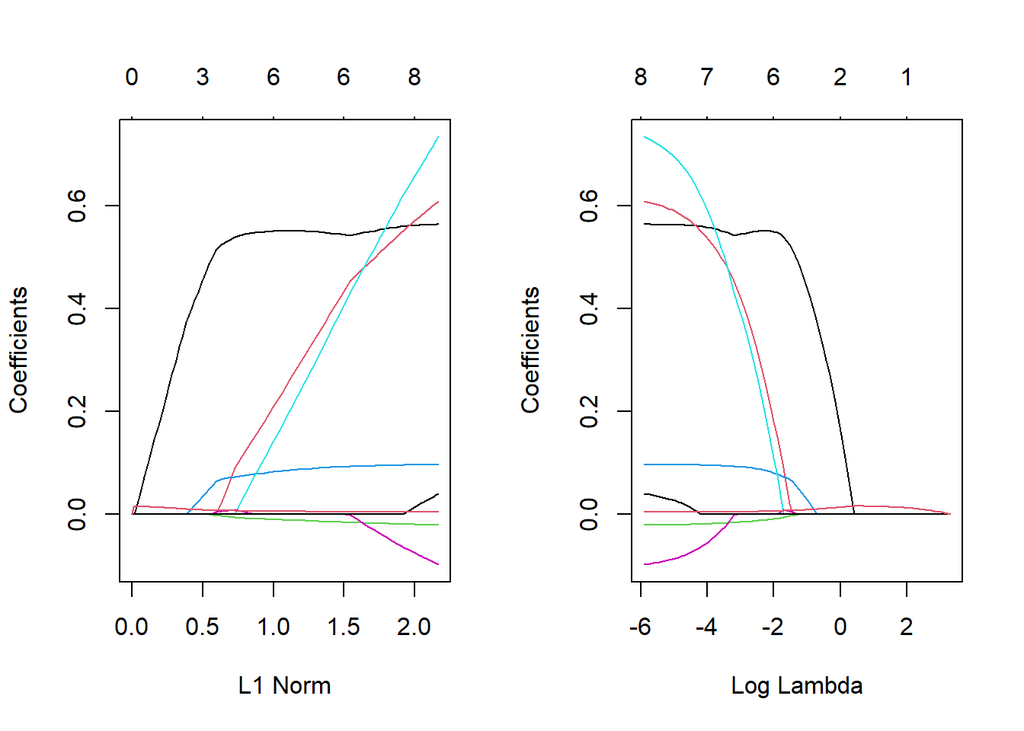

```r
fit_elasticnet <- glmnet(X, y, family = c("gaussian"), alpha = .5, standardize  = FALSE)
par(mfrow = c(1, 2))
plot(fit_elasticnet)
plot(fit_elasticnet, xvar = "lambda", label = TRUE)
```

### Some thoghts about regularization

- Interpretation.
- Objective of the study.

## Other shrinkage examples

### Principal Components

- Dimension reduction.
- All variables are reduced into a few “principal components” that are linear combinations of said variables.
- Helpful for cases that present collinearity.

```r
pca <- prcomp(dd)
pca
```

```
## Standard deviations (1, .., p=10):
##  [1] 28.3128508  7.1567817  1.5647572  1.3808222  0.8129917  0.5710866
##  [7]  0.4881765  0.4136752  0.3298806  0.2713449
##
## Rotation (n x k) = (10 x 10):
##                 PC1          PC2         PC3          PC4          PC5
## lcavol  0.018209408  0.016873128 -0.60226447 -0.096028751 -0.189062877
## lweight 0.001733282  0.020076745 -0.09288546  0.109978129 -0.076095426
## age     0.077590211  0.993864995  0.01728889 -0.072237987  0.007021371
## lbph    0.004375509  0.071633091 -0.06293385  0.970367573  0.157836437
## svi     0.006704749 -0.001112326 -0.13664589 -0.051679105  0.049232261
## lcp     0.031208032 -0.012011062 -0.54156574 -0.127311476  0.775311057
## gleason 0.019215746  0.004958514 -0.04232931 -0.007612331 -0.007549060
## pgg45   0.995959332 -0.077956766  0.03836989  0.005570729 -0.012100079
## lpsa    0.017321304  0.008215582 -0.55417421  0.109018476 -0.572842885
## train   0.001694013  0.009922213  0.04529459 -0.031603567 -0.040244907
##                  PC6          PC7          PC8          PC9         PC10
## lcavol   0.671290542  0.358944315  0.094572994  0.011688492 -0.056055777
## lweight -0.154894134  0.021776013  0.179714119  0.946642705 -0.142072328
## age     -0.014059758 -0.011933186  0.009168881 -0.013345716  0.006583614
## lbph     0.094407842  0.064132049 -0.037880421 -0.092203422 -0.037432071
## svi     -0.197564040  0.007911475  0.005382256 -0.179720175 -0.951191208
## lcp     -0.226551635 -0.070686058 -0.060086870  0.025118571  0.166461277
## gleason  0.384150965 -0.659546669 -0.610006091  0.172544720 -0.115093780
## pgg45   -0.001450991  0.011953094  0.013798218 -0.000957456  0.001330172
## lpsa    -0.490045822 -0.233226076 -0.085297103 -0.146235623  0.171142213
## train   -0.195422946  0.609779686 -0.757645677  0.104707457  0.014718193
```

```r
# factoextra::fviz_pca_biplot(pca, label = "var", repel = TRUE)
```

[Helpful visualization of dimension reduction](https://i.sstatic.net/Q7HIP.gif)

## For next class

- We’ll focus on a project example (including post-hoc mean comparisons).